# Venn Diagram Calculation

Edie Espejo

10/18/2021

# Stata Tabulations

The Stata code below outputs the subsequent table. It represents the distribution $P(A3, A4 | PM=0)$.

```
tabout binaryattitude3 binaryattitude4 if subpop & pillsmax==0 using "../tables/plottables/binaryattitude3-binaryattitude4-pillsmax0.csv", svy cells(cell) format(4) replace
```

| …1 | binary, willing to stop take meds | …3 | …4 |
| --- | --- | --- | --- |
| binary, take more meds than needed | disagree | agree | Total |
| NA | Prop. | Prop. | Prop. |
| disagree | 0.1085 | 0.6618 | 0.7703 |
| agree | 0.0172 | 0.2125 | 0.2297 |
| Total | 0.1256 | 0.8744 | 1.0000 |

The next table represents $P(A3, A4 | PM=1)$.

```
tabout binaryattitude3 binaryattitude4 if subpop & pillsmax==1 using "../tables/plottables/binaryattitude3-binaryattitude4-pillsmax1.csv", svy cells(cell) format(4) replace
```

| …1 | binary, willing to stop take meds | …3 | …4 |
| --- | --- | --- | --- |
| binary, take more meds than needed | disagree | agree | Total |
| NA | Prop. | Prop. | Prop. |
| disagree | 0.1096 | 0.6133 | 0.7229 |
| agree | 0.0110 | 0.2662 | 0.2771 |
| Total | 0.1206 | 0.8794 | 1.0000 |

The survey-weighted probabilities for $P(PM=1)$ and $P(PM=0)$ are calculated using the following Stata code.

```
tabout pillsmax if subpop using "../tables/plottables/pillsmax.csv", svy cells(cell) format(4) replace
```

| uncomfortable taking 5 or more pills | Prop. |
| --- | --- |
| disagree | 0.5125 |
| agree | 0.4875 |
| Total | 1.0000 |

# Venn Diagram Calculations

The following value represents the survey-weighted $P(PM=0)$.

```r
disagree_prop <- as.numeric(pm_dist[1,'Prop.'])
disagree_prop
```

```
## [1] 0.5125
```

Then, we could calculate $P(A3,A4|PM=0) \cdot P(PM=0)$.

|  | disagree | agree | total |
| --- | --- | --- | --- |
| disagree | 5.560625 | 33.91725 | 39.47787 |
| agree | 0.881500 | 10.89062 | 11.77213 |
| total | 6.437000 | 44.81300 | 51.25000 |

The following value represents the survey-weighted $P(PM=1)$.

```r
agree_prop <- as.numeric(pm_dist[2,'Prop.'])
agree_prop
```

```
## [1] 0.4875
```

Then, we could calculate $P(A3,A4|PM=1) \cdot P(PM=1)$.

|  | disagree | agree | total |
| --- | --- | --- | --- |
| disagree | 5.34300 | 29.89838 | 35.24137 |
| agree | 0.53625 | 12.97725 | 13.50863 |
| total | 5.87925 | 42.87075 | 48.75000 |

We can collapse these dataframes. I am melting the 2x2 contingency table for $PM=0$, adding a column that indicates $PM=0$ for these frequencies, then changing the values from attitudinal values from Agree/Disagree to 0/1.

```r
a <- pm_0_calculation[1:2, 1:3]
names(a)[1] <- 'placeholder'
a2 <- a %>%
  reshape2::melt(id.vars='placeholder') %>%
  mutate(pillsmax=0) %>%
  rename(binaryattitude3=placeholder) %>%
  rename(binaryattitude4=variable) %>%
  mutate(binaryattitude3=ifelse(binaryattitude3=='agree', 1, 0)) %>%
  mutate(binaryattitude4=ifelse(binaryattitude4=='agree', 1, 0)) %>%
  select(binaryattitude3, binaryattitude4, pillsmax, value)
```

| binaryattitude3 | binaryattitude4 | pillsmax | value |
| --- | --- | --- | --- |
| 0 | 0 | 0 | 5.560625 |
| 1 | 0 | 0 | 0.881500 |
| 0 | 1 | 0 | 33.917250 |
| 1 | 1 | 0 | 10.890625 |

After repeating the same calculation with the $PM=1$ table, we can construct a 3-way survey-weighted table by binding the rows together. Recall that `value` is the overall percentage.

| binaryattitude3 | binaryattitude4 | pillsmax | value |
| --- | --- | --- | --- |
| 1 | 1 | 1 | 12.9772 |
| 1 | 1 | 0 | 10.8906 |
| 1 | 0 | 1 | 0.5362 |
| 1 | 0 | 0 | 0.8815 |
| 0 | 1 | 1 | 29.8984 |
| 0 | 1 | 0 | 33.9172 |
| 0 | 0 | 1 | 5.3430 |
| 0 | 0 | 0 | 5.5606 |

Notice that if we sum up the `value` column, we get a total of 100.0047 which is slightly above 100%. This is due to rounding error.

# Plotting Venn Diagaam

Recall our current Venn diagram looked like this.

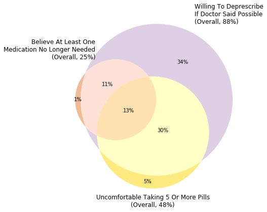

```r
knitr::include_graphics('../plots/venn-3way-svy.png')
```

We will recreate in R. It will not be to scale, but it is based off of the calculations above. The Venn diagram above can be used for comparisons.

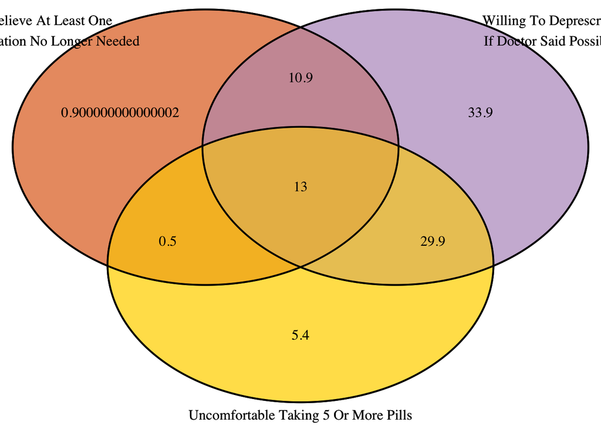

```r
k <- 1
p <- draw.triple.venn(area1=percent_grid %>%
                        filter(binaryattitude3==1) %>%
                        pull(value) %>%
                        sum() %>%
                        round(digits=k),

                      area2=percent_grid %>%
                        filter(binaryattitude4==1) %>%
                        pull(value) %>%
                        sum() %>%
                        round(digits=k),

                      area3=percent_grid %>%
                        filter(pillsmax==1) %>%
                        pull(value) %>%
                        sum() %>%
                        round(digits=k),

                      n12=percent_grid %>%
                        filter(binaryattitude3==1 & binaryattitude4==1) %>%
                        pull(value) %>%
                        sum() %>%
                        round(digits=k),

                      n23=percent_grid %>%
                        filter(binaryattitude4==1 & pillsmax==1) %>%
                        pull(value) %>%
                        sum() %>%
                        round(digits=k),

                      n13=percent_grid %>%
                        filter(binaryattitude3==1 & pillsmax==1) %>%
                        pull(value) %>%
                        sum() %>%
                        round(digits=k),

                      n123=percent_grid %>%
                        filter(binaryattitude3==1 & binaryattitude4==1 & pillsmax==1) %>%
                        pull(value) %>%
                        sum() %>%
                        round(digits=k),

                     category=c('Believe At Least One\nMedication No Longer Needed',
                                'Willing To Deprescribe\nIf Doctor Said Possible',
                                'Uncomfortable Taking 5 Or More Pills'),
                     fill=c('#E47833', '#BDA0CB', 'gold'))
grid.draw(p)
```

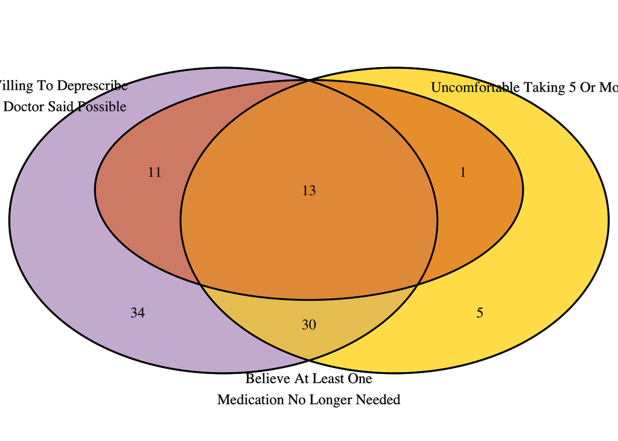

```r
p <- draw.triple.venn(area1=25,

                      area2=88,

                      area3=49,

                      n12=24,

                      n23=43,

                      n13=14,

                      n123=13,

                     category=c('Believe At Least One\nMedication No Longer Needed',
                                'Willing To Deprescribe\nIf Doctor Said Possible',
                                'Uncomfortable Taking 5 Or More Pills'),
                     fill=c('#E47833', '#BDA0CB', 'gold'))
grid.draw(p)
```

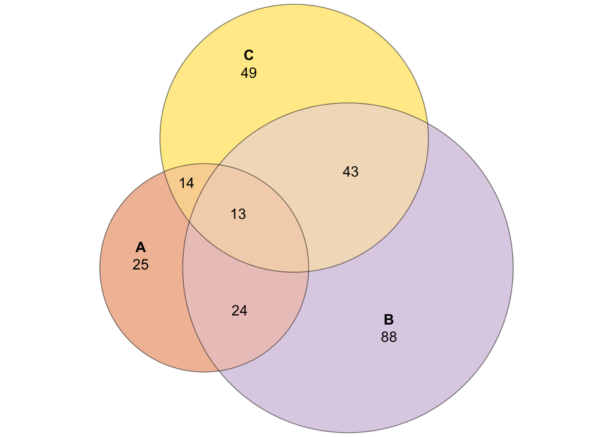

```r
library(eulerr)
k<-0

VennDiag <- euler(c("A" = percent_grid %>%
                        filter(binaryattitude3==1) %>%
                        pull(value) %>%
                        sum() %>%
                        round(digits=k),

                    "B" = percent_grid %>%
                        filter(binaryattitude4==1) %>%
                        pull(value) %>%
                        sum() %>%
                        round(digits=k),

                    "C" = percent_grid %>%
                        filter(pillsmax==1) %>%
                        pull(value) %>%
                        sum() %>%
                        round(digits=k),

                    "A&B" = percent_grid %>%
                        filter(binaryattitude3==1 & binaryattitude4==1) %>%
                        pull(value) %>%
                        sum() %>%
                        round(digits=k),

                    "B&C" = percent_grid %>%
                        filter(binaryattitude4==1 & pillsmax==1) %>%
                        pull(value) %>%
                        sum() %>%
                        round(digits=k),

                    "A&C" = percent_grid %>%
                        filter(binaryattitude3==1 & pillsmax==1) %>%
                        pull(value) %>%
                        sum() %>%
                        round(digits=k),

                    "A&B&C" = percent_grid %>%
                        filter(binaryattitude3==1 & binaryattitude4==1 & pillsmax==1) %>%
                        pull(value) %>%
                        sum() %>%
                        round(digits=k)))

plot(VennDiag, quantities = TRUE, font=1, cex=1, alpha=0.5,
     fill=c('#E47833', '#BDA0CB', 'gold'))
```

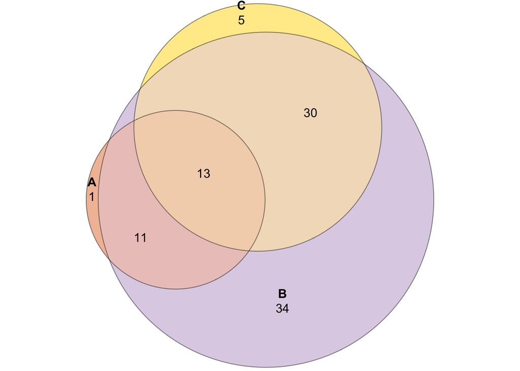

```r
library(eulerr)
VennDiag <- euler(c("A" = 1, "B" = 34, "C" = 5, "A&B" = 11, "B&C" = 30,
                    "A&C" = 0.5, "A&B&C" = 13))
plot(VennDiag, quantities = TRUE, font=1, cex=1, alpha=0.5,
     fill=c('#E47833', '#BDA0CB', 'gold'))
```